# Question 8.1

#### Describe a situation or problem from your job, everyday life, current events, etc., for which a linear regression model would be appropriate. List some (up to 5) predictors that you might use.

### Answer

#### I have an online clothing store, a situation where a linear regression model could be appropriate is predicting the sales revenue for upcoming months based on various factors.

#### Some predictors:

#### - Web traffic: higher web traffic (number of visitors to the online store's website) leads to higher sales opportunities.

#### - Seasons: The sales are also affected by seasonal situations such as weather and holiday seasons.

#### - Price and discounts: The sales are affected by pricing strategies including discounts, promotions, and price changes.

#### - Marketing: email promotions, online advertising, pay-per-click campaigns can affect the sales.

# Question 8.2

```r
data <- read.table("./data 8.2/uscrime.txt", header = TRUE)
```

```r
head(data)
```

| M | So | Ed | Po1 | Po2 | LF | M.F | Pop | NW | U1 | U2 | Wealth | Ineq | Prob | Time | Crime |
| --- | --- | --- | --- | --- | --- | --- | --- | --- | --- | --- | --- | --- | --- | --- | --- |
| 15.1 | 1 | 9.1 | 5.8 | 5.6 | 0.510 | 95.0 | 33 | 30.1 | 0.108 | 4.1 | 3940 | 26.1 | 0.084602 | 26.2011 | 791 |
| 14.3 | 0 | 11.3 | 10.3 | 9.5 | 0.583 | 101.2 | 13 | 10.2 | 0.096 | 3.6 | 5570 | 19.4 | 0.029599 | 25.2999 | 1635 |
| 14.2 | 1 | 8.9 | 4.5 | 4.4 | 0.533 | 96.9 | 18 | 21.9 | 0.094 | 3.3 | 3180 | 25.0 | 0.083401 | 24.3006 | 578 |
| 13.6 | 0 | 12.1 | 14.9 | 14.1 | 0.577 | 99.4 | 157 | 8.0 | 0.102 | 3.9 | 6730 | 16.7 | 0.015801 | 29.9012 | 1969 |
| 14.1 | 0 | 12.1 | 10.9 | 10.1 | 0.591 | 98.5 | 18 | 3.0 | 0.091 | 2.0 | 5780 | 17.4 | 0.041399 | 21.2998 | 1234 |
| 12.1 | 0 | 11.0 | 11.8 | 11.5 | 0.547 | 96.4 | 25 | 4.4 | 0.084 | 2.9 | 6890 | 12.6 | 0.034201 | 20.9995 | 682 |

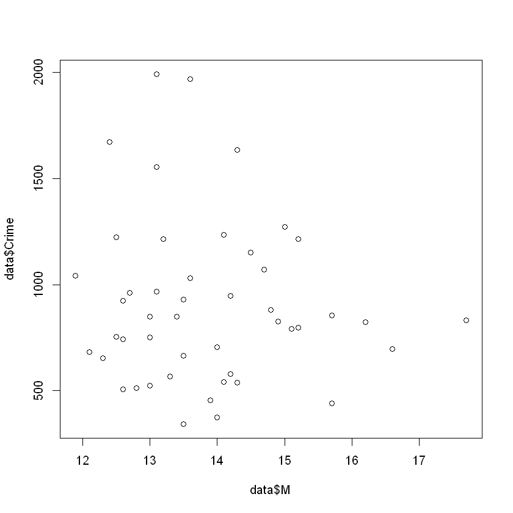

```r
plot(data$M, data$Crime)
```

```r
model <- lm(Crime ~ M + So + Ed + Po1 + Po2 + LF + M.F + Pop + NW + U1 + U2 + Wealth + Ineq + Prob + Time, data = data)
```

```r
summary(model)
```

```
Call:
lm(formula = Crime ~ M + So + Ed + Po1 + Po2 + LF + M.F + Pop +
    NW + U1 + U2 + Wealth + Ineq + Prob + Time, data = data)

Residuals:
    Min      1Q  Median      3Q     Max
-395.74  -98.09   -6.69  112.99  512.67

Coefficients:
              Estimate Std. Error t value Pr(>|t|)
(Intercept) -5.984e+03  1.628e+03  -3.675 0.000893 ***
M            8.783e+01  4.171e+01   2.106 0.043443 *
So          -3.803e+00  1.488e+02  -0.026 0.979765
Ed           1.883e+02  6.209e+01   3.033 0.004861 **
Po1          1.928e+02  1.061e+02   1.817 0.078892 .
Po2         -1.094e+02  1.175e+02  -0.931 0.358830
LF          -6.638e+02  1.470e+03  -0.452 0.654654
M.F          1.741e+01  2.035e+01   0.855 0.398995
Pop         -7.330e-01  1.290e+00  -0.568 0.573845
NW           4.204e+00  6.481e+00   0.649 0.521279
U1          -5.827e+03  4.210e+03  -1.384 0.176238
U2           1.678e+02  8.234e+01   2.038 0.050161 .
Wealth       9.617e-02  1.037e-01   0.928 0.360754
Ineq         7.067e+01  2.272e+01   3.111 0.003983 **
Prob        -4.855e+03  2.272e+03  -2.137 0.040627 *
Time        -3.479e+00  7.165e+00  -0.486 0.630708
---
Signif. codes:  0 '***' 0.001 '**' 0.01 '*' 0.05 '.' 0.1 ' ' 1

Residual standard error: 209.1 on 31 degrees of freedom
Multiple R-squared:  0.8031,	Adjusted R-squared:  0.7078
F-statistic: 8.429 on 15 and 31 DF,  p-value: 3.539e-07
```

```r
# Try to fit data into a linear regression model
```

```r
#Crime rate in a city:
crime_city <- data.frame(
    M = 14.0,
    So = 0,
    Ed = 10.0,
    Po1 = 12.0,
    Po2 = 15.5,
    LF = 0.640,
    M.F = 94.0,
    Pop = 150,
    NW = 1.1,
    U1 = 0.120,
    U2 = 3.6,
    Wealth = 3200,
    Ineq = 20.1,
    Prob = 0.04,
    Time = 39.0
)
```

```r
uscrime_model <- lm(Crime ~ ., data = data)
summary(uscrime_model)
```

```
Call:
lm(formula = Crime ~ ., data = data)

Residuals:
    Min      1Q  Median      3Q     Max
-395.74  -98.09   -6.69  112.99  512.67

Coefficients:
              Estimate Std. Error t value Pr(>|t|)
(Intercept) -5.984e+03  1.628e+03  -3.675 0.000893 ***
M            8.783e+01  4.171e+01   2.106 0.043443 *
So          -3.803e+00  1.488e+02  -0.026 0.979765
Ed           1.883e+02  6.209e+01   3.033 0.004861 **
Po1          1.928e+02  1.061e+02   1.817 0.078892 .
Po2         -1.094e+02  1.175e+02  -0.931 0.358830
LF          -6.638e+02  1.470e+03  -0.452 0.654654
M.F          1.741e+01  2.035e+01   0.855 0.398995
Pop         -7.330e-01  1.290e+00  -0.568 0.573845
NW           4.204e+00  6.481e+00   0.649 0.521279
U1          -5.827e+03  4.210e+03  -1.384 0.176238
U2           1.678e+02  8.234e+01   2.038 0.050161 .
Wealth       9.617e-02  1.037e-01   0.928 0.360754
Ineq         7.067e+01  2.272e+01   3.111 0.003983 **
Prob        -4.855e+03  2.272e+03  -2.137 0.040627 *
Time        -3.479e+00  7.165e+00  -0.486 0.630708
---
Signif. codes:  0 '***' 0.001 '**' 0.01 '*' 0.05 '.' 0.1 ' ' 1

Residual standard error: 209.1 on 31 degrees of freedom
Multiple R-squared:  0.8031,	Adjusted R-squared:  0.7078
F-statistic: 8.429 on 15 and 31 DF,  p-value: 3.539e-07
```

```r
# Coefficients
coefficients(model)
```

**(Intercept)**

-5984.2876044968

**M**

87.8301732430489

**So**

-3.80345029611503

**Ed**

188.32431475042

**Po1**

192.80433827659

**Po2**

-109.421925381633

**LF**

-663.826145079777

**M.F**

17.4068555276353

**Pop**

-0.733008149584913

**NW**

4.20446100194136

**U1**

-5827.10272440482

**U2**

167.799672221837

**Wealth**

0.0961662430048667

**Ineq**

70.6720994522301

**Prob**

-4855.26581547548

**Time**

-3.47901784343313

#### - M, Ed, Po1, U2, Ineq have positive coefficients suggesting that higher values are associated with higher crime rate

#### - So, Po2, LF, M.F, Pop, NW, U1, Wealth, Time are not significant because they have p-value > 0.05

#### - Prob has a negative coefficient, which indicates that a higher probability of imprisonment is associated with lower crime rates.

#### R-squared is 0.8031 or 80.31% of the data can be explained by the predictor variables in the model.

#### Adjusted R-squared is 70.78%

#### Residual standard error is 209.1

#### F-statistic: Tests the overall significance of the model. The low p-value (3.539e-07) suggests that the model is statistically significant at a high confidence level.

```r
predicted_crime_rate <- predict(model, newdata = crime_city)
predicted_crime_rate
```

**1:** 155.434896887443

### The result of US crime is 155.4349